# Actividad seminario - 07MBIG Visualización de Datos

#### Nombre: Luis Javier Cuadros Noguera

#### Fuente: https://www.kaggle.com/skihikingkevin/csgo-matchmaking-damage/

## Introducción

En esta actividad voy a utilizar un dataset de los que utilizaré en mi TFM. Este dataset contiene registros sobre un gran número de partidas reales del videojuego Counter Strike. Los datos son del modo de juego competitivo, que consiste en un partido de dos equipos de cinco personas cada uno, el cual gana el mejor de 30 rondas, es decir, gana el equipo que consiga ganar 16 rondas, o existe empate en el caso de que el partido quede 15-15. En el juego existen dos bandos, los cuales definiremos como 'Policías' contra 'Terroristas', el objetivo de los policias es detener a los terroristas, los cuales intentan colocar un explosivo, si estos consiguen detonar el explosivo habrán ganado la ronda, si no lo consiguen, la ganan los policías. El partido se divide en dos mitades de 15 rondas cada una, cuando se llega a la ronda 15, los bandos se invierten. Se dice que la primera ronda de cada parte es muy importante, ya que quien la gana consigue un dinero extra para poder comprar un mejor equipamiento y ademas el equipo perdedor queda debilitado, al perder las armas y tener que volver a comprarlas. El objetivo de la práctica es analizar esta primera ronda para poder sacar conocimiento de estos datos y poder tener cierta 'ventaja estratégica'

## ¿A quién va dirigida la presentación?

Esta presentación estará dirigida a jugadores habituales del videojuego Counter Strike que estén interesados en un análisis más detallado del juego.

## ¿Cuál es el objetivo?

El objetivo será mostrar información relevante y que pueda ser útil a la hora de mejorar en el juego.

## Herramientas que usaremos

Para hacer la actividad me he basado en:

- Cuaderno de jupyter notebook

  Para ejecutar código mediante el que manipularé los datos, ya que se trata de un dataset grande. Me he decantado por el lenguaje python porque es el que estoy más habituado a utilizar y con el que más cómodo me siento. Además de eso nos permite utilizar varias librerias que nos van a facilitar el trabajo.
- Google sheet

  Lo uso para previsualizar rápidamente el dataset y saber cómo 'atacarlo'
- Datawrapper

  Lo usaré para generar los gráficos interactivos

## Metodología

Para empezar vamos a importar varias bibliotecas que nos serán útiles más tarde

```python
import pandas as pd
import io
import requests
import seaborn as sns
import timeit
import matplotlib.pyplot as plt
from skimage.io import imread
```

A continuación necesito cargar los datos. Los voy a guardar en dos dataframes, uno que contiene los valores cuantitativos y otro que contiene coordenadas para dibujar sobre los mapas del juego

```python
df = pd.read_csv('C:/Users/Javi/Desktop/visualizacion/dataset/mm_master_demos.csv', index_col=0)
df_mapas = pd.read_csv('C:/Users/Javi/Desktop/visualizacion/dataset/map_data.csv', index_col=0)
```

Una vez que tenemos los mapas cargados podemos ver unos pocos registros para ver si se han cargado correctamente

```python
df.head()
```

|  | file | map | date | round | tick | seconds | att_team | vic_team | att_side | vic_side | ... | vic_id | vic_rank | att_pos_x | att_pos_y | vic_pos_x | vic_pos_y | round_type | ct_eq_val | t_eq_val | avg_match_rank |
| --- | --- | --- | --- | --- | --- | --- | --- | --- | --- | --- | --- | --- | --- | --- | --- | --- | --- | --- | --- | --- | --- |
| 0 | 003201673717864202280_0171883906.dem | de_dust2 | 09/28/2017 8:44:22 PM | 1 | 8482 | 133.0582 | Team 1 | Team 2 | CounterTerrorist | Terrorist | ... | 76561198123082770 | 17 | 1473.847 | 1351.358 | 662.170 | 772.748 | PISTOL_ROUND | 2950 | 3850 | 16.0 |
| 1 | 003201673717864202280_0171883906.dem | de_dust2 | 09/28/2017 8:44:22 PM | 1 | 8600 | 134.9023 | Team 1 | Team 2 | CounterTerrorist | Terrorist | ... | 76561198051040004 | 17 | -1211.723 | 1060.813 | -1184.006 | 1153.343 | PISTOL_ROUND | 2950 | 3850 | 16.0 |
| 2 | 003201673717864202280_0171883906.dem | de_dust2 | 09/28/2017 8:44:22 PM | 1 | 8610 | 135.0586 | Team 2 | Team 1 | Terrorist | CounterTerrorist | ... | 76561198223006752 | 16 | -1153.584 | 1163.131 | -1198.015 | 1050.423 | PISTOL_ROUND | 2950 | 3850 | 16.0 |
| 3 | 003201673717864202280_0171883906.dem | de_dust2 | 09/28/2017 8:44:22 PM | 1 | 8624 | 135.2774 | Team 1 | Team 2 | CounterTerrorist | Terrorist | ... | 76561198051040004 | 17 | -1173.053 | 1044.365 | -1141.785 | 1190.089 | PISTOL_ROUND | 2950 | 3850 | 16.0 |
| 4 | 003201673717864202280_0171883906.dem | de_dust2 | 09/28/2017 8:44:22 PM | 1 | 8632 | 135.4024 | Team 2 | Team 1 | Terrorist | CounterTerrorist | ... | 76561198223006752 | 16 | -1142.522 | 1200.967 | -1157.690 | 1050.702 | PISTOL_ROUND | 2950 | 3850 | 16.0 |

5 rows × 32 columns

```python
df_mapas.head()
```

|  | EndX | EndY | ResX | ResY | StartX | StartY |
| --- | --- | --- | --- | --- | --- | --- |
| de_cache | 3752 | 3187 | 1024 | 1024 | -2031 | -2240 |
| de_cbble | 2282 | 3032 | 1024 | 1024 | -3819 | -3073 |
| de_dust2 | 2127 | 3455 | 1024 | 1024 | -2486 | -1150 |
| de_inferno | 2797 | 3800 | 1024 | 1024 | -1960 | -1062 |
| de_mirage | 1912 | 1682 | 1024 | 1024 | -3217 | -3401 |

A continuación procedemos a la limpieza de los datos. Nos quedamos con los mapas que más se juegan en la actualidad, ya que son en los que tendrá interés el lector

```python
mapas = ['de_cache','de_dust2','de_inferno','de_mirage','de_overpass']
df = df[df['map'].isin(mapas)]
df = df.reset_index(drop=True)
md = df_mapas.loc[df['map']]
md[['att_pos_x', 'att_pos_y', 'vic_pos_x', 'vic_pos_y']] = (df.set_index('map')[['att_pos_x', 'att_pos_y', 'vic_pos_x', 'vic_pos_y']])
md['att_pos_x'] = (md['ResX']*(md['att_pos_x']-md['StartX']))/(md['EndX']-md['StartX'])
md['att_pos_y'] = (md['ResY']*(md['att_pos_y']-md['StartY']))/(md['EndY']-md['StartY'])
md['vic_pos_x'] = (md['ResX']*(md['vic_pos_x']-md['StartX']))/(md['EndX']-md['StartX'])
md['vic_pos_y'] = (md['ResY']*(md['vic_pos_y']-md['StartY']))/(md['EndY']-md['StartY'])
df[['att_pos_x', 'att_pos_y', 'vic_pos_x', 'vic_pos_y']] = md[['att_pos_x', 'att_pos_y', 'vic_pos_x', 'vic_pos_y']].values
```

Nos quedamos con los datos de las primeras rondas, es decir, la 1 y la 16 y las armas que nos interesan

```python
armas = ['USP', 'Glock', 'P2000', 'P250', 'Tec9', 'FiveSeven', 'Deagle', 'DualBarettas', 'CZ']
df_pistolas = df[(df['round'].isin([1,16])) & (df['wp'].isin(armas))]
```

Ahora realizamos un cálculo para ver en porcentaje cuáles son las armas más compradas en estas rondas y la media de daño que realiza cada arma por ronda.

```python
compra_pistolas = df_pistolas.groupby(['file', 'round', 'att_side', 'wp'])['hp_dmg'].first()
(compra_pistolas.groupby(['wp']).count()/compra_pistolas.groupby(['wp']).count().sum())*100.
```

```
wp
CZ               1.827676
Deagle           4.563515
DualBarettas     1.509820
FiveSeven        5.437621
Glock           26.575094
P2000           11.817459
P250             9.717335
Tec9             5.074356
USP             33.477126
Name: hp_dmg, dtype: float64
```

```python
df_pistolas.groupby(['file', 'round', 'wp', 'att_id'])['hp_dmg'].sum().groupby('wp').agg(['mean']).sort_values(by='mean')
```

| wp | mean |
| --- | --- |
| Tec9 | 87.910448 |
| DualBarettas | 89.222222 |
| P250 | 90.631088 |
| FiveSeven | 91.564286 |
| CZ | 91.880682 |
| Glock | 95.173295 |
| P2000 | 97.300871 |
| USP | 98.977444 |
| Deagle | 100.417808 |

Vamos a guardar estos dataframes en un fichero csv para posteriormente poder graficar con ellos en datawrapper

```python
graf_danio = df_pistolas.groupby(['file', 'round', 'wp', 'att_id'])['hp_dmg'].sum().groupby('wp').agg(['mean']).sort_values(by='mean')
```

```python
compra_pistolas.to_csv('compras.csv', header=False, index=False)
graf_danio.to_csv('danio.csv', header=False, index=False)
```

Para terminar, vamos a dibujar en un mapa la zona de influencia del bando policia y terrorista. He elegido el mapa Dust 2, ya que es el mapa más jugado del juego y por tanto el que mayor interés puede causar

[figure not shown]

```python
smap = 'de_dust2'

bg = imread('C:/Users/Javi/Desktop/visualizacion/dataset/'+smap+'.png')
fig, (ax1, ax2) = plt.subplots(1,2,figsize=(18,16))

ax1.grid(b=True, which='major', color='w', linestyle='--', alpha=0.25)
ax2.grid(b=True, which='major', color='w', linestyle='--', alpha=0.25)

ax1.imshow(bg, zorder=0, extent=[0.0, 1024, 0., 1024])
ax2.imshow(bg, zorder=0, extent=[0.0, 1024, 0., 1024])

plt.xlim(0,1024)
plt.ylim(0,1024)

plot_df = df_pistol.loc[(df_pistol.map == smap) & (df_pistol.att_side == 'Terrorist')]
sns.kdeplot(plot_df['att_pos_x'], plot_df['att_pos_y'], cmap='YlOrBr', bw=15, ax=ax1)
ax1.set_title('Terroristas')

plot_df = df_pistol.loc[(df_pistol.map == smap) & (df_pistol.att_side == 'Terrorist')]
sns.kdeplot(plot_df['att_pos_x'], plot_df['att_pos_y'], cmap='Blues', bw=15, ax=ax2)
ax2.set_title('Policias')
```

## Presentación

Una vez tenemos todos los datos, representamos los gráficos más interesantes

#### Media de veces que se utiliza cada arma

He utilizado un diagrama circular para representar el porcentaje de uso de cada arma en las rondas 1 y 16.

[figure not shown]

https://www.datawrapper.de/_/g1kij/

#### Media de daño que causa cada arma

Para esto he visto más apropiado utilizar un gráfico de barras verticales.

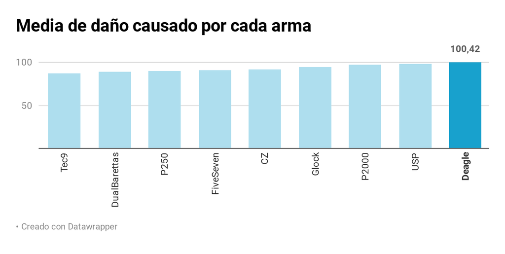

Podemos ver que Deagle es el arma que más daño hace de media, esto tambien tiene sentido, puesto que es el arma más potente que se puede comprar en las primeras rondas de cada parte. El problema que conlleva comprarla es que no te queda dinero suficiente para comprar chaleco antibalas, por lo que es una decisión de riesgo.

https://www.datawrapper.de/_/2XGVy/

#### Impacto de cada bando sobre el mapa

[figure not shown]

En el gráfico se puede observar las zonas donde hay más acción(se produce más daño a los jugadores). Es interesante ver como la mayoría del daño se genera en zonas cercanas a donde los terroristas deben colocar el explosivo.